# Time series models

## fit an ARIMA(2,0,2)

```r
((fit <- arima(uschange[,"Consumption"],order = c(2,0,2))))
```

```
Call:
arima(x = uschange[, "Consumption"], order = c(2, 0, 2))

Coefficients:
         ar1      ar2      ma1     ma2  intercept
      1.3908  -0.5813  -1.1800  0.5584     0.7463
s.e.  0.2553   0.2078   0.2381  0.1403     0.0845

sigma^2 estimated as 0.3417:  log likelihood = -165.14,  aic = 342.28
```

```r
coef <- coefficients(fit)
ar1=round(coef['ar1'],3) %>% unname()
ar2=round(coef['ar2'],3) %>% unname()
intercept = round(coef['intercept'] * (1-coef['ar1'] - coef['ar2']),3) %>% unname()
ma1=round(coef['ma1'],3) %>% unname()
ma2=round(coef['ma2'],3) %>% unname()
sigma=round(sqrt(fit$sigma2),3) %>% unname()
sigma2=round(fit$sigma2,3) %>% unname()
```

## The estimated model

- $y_t = c + 1.391y_{t-1} -0.581y_{t-2}-1.18 \varepsilon_{t-1}+ 0.558\varepsilon_{t-2}+ \varepsilon_{t}$
- where $c= 0.142$
- and $\varepsilon_t$ is white noise with a standard deviation of $0.585 = \sqrt{0.342}$.

## Forecasts from estimated model

### The forecasted data

- The data is point estimates based on some frequentist asymptotic theory

```r
fit %>% forecast(h=10)
```

```
        Point Forecast        Lo 80    Hi 80      Lo 95    Hi 95
2016 Q4      0.7502795  0.001108855 1.499450 -0.3954781 1.896037
2017 Q1      0.7894265  0.023789630 1.555063 -0.3815141 1.960367
2017 Q2      0.8039764  0.012001551 1.595951 -0.4072446 2.015197
2017 Q3      0.8014580 -0.012967301 1.615883 -0.4440980 2.047014
2017 Q4      0.7894979 -0.037980785 1.616976 -0.4760215 2.055017
2018 Q1      0.7743270 -0.058387145 1.607041 -0.4991994 2.047853
2018 Q2      0.7601787 -0.073727533 1.594085 -0.5151708 2.035528
2018 Q3      0.7493189 -0.084623827 1.583262 -0.5260865 2.024724
2018 Q4      0.7424386 -0.091640109 1.576517 -0.5331747 2.018052
2019 Q1      0.7391815 -0.095286207 1.573649 -0.5370267 2.015390
```

## Forecasts from estimated model

### Plotting the forecasts

- The points estimates are visualised as banded limits at the 80% and 95% forecasting levels

```r
fit %>% forecast(h=10) %>% autoplot(include=80)
```

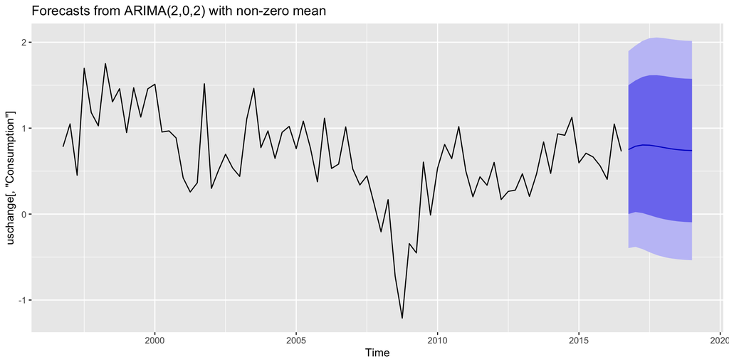

### What is the Correct Interpretation of a 95% Confidence Interval for a Population Mean?

- **A.** There is a 95% probability that the population mean falls within the calculated confidence interval.
- **B.** If we were to draw 100 different samples and compute a 95% confidence interval for each sample, we would expect about 95 of these intervals to contain the population mean.
- **C.** The population mean is 95% likely to be the center point of the calculated confidence interval.
- **D.** There is a 95% chance that any given sample mean falls within the calculated confidence interval.
- **E.** The calculated confidence interval captures the range within which 95% of the population data falls.

## Understanding ARIMA models

- If $c=0$ and $d=0$, the long-term forecasts will go to zero.
- If $c=0$ and $d=1$, the long-term forecasts will go to a non-zero constant.
- If $c=0$ and $d=2$, the long-term forecasts will follow a straight line.
- If $c\ne0$ and $d=0$, the long-term forecasts will go to the mean of the data.
- If $c\ne0$ and $d=1$, the long-term forecasts will follow a straight line.
- If $c\ne0$ and $d=2$, the long-term forecasts will follow a quadratic trend.

## Understanding ARIMA models

### Forecast variance and $d$

- The higher the value of $d$, the more rapidly the prediction intervals increase in size.
- For $d=0$, the long-term forecast standard deviation will go to the standard deviation of the historical data.

## Understanding ARIMA models

### Cyclic behaviour

- For cyclic forecasts, $p\ge2$ and some restrictions on coefficients are required.
- If $p=2$, we need $\phi_1^2+4\phi_2<0$. Then average length of stochastic cycles is

$$(2\pi)/\left[\text{arc cos}(-\phi_1(1-\phi_2)/(4\phi_2))\right].$$

- This formula has important uses in estimation business and economic cycles. (See Example 2.3 in Tsay (2010))

## Model building

### Maximum likelihood estimation (MLE)

- Having identified the model order, we need to estimate the parameters $c,\phi_1,\dots,\phi_p \text{ }\theta_1,\dots,\theta_q$.
- MLE is very similar to least squares estimation obtained by minimizing $\sum_{t-1}^T e_t^2$
- The `Arima()` command allows MLE estimation and constrained least squares(CLS).
- Non-linear optimization must be used in either case.
- Different software will give different estimates.

## Partial autocorrelations

- Partial autocorrelations} measure relationship between $y_{t}$ and $y_{t - k}$, when the effects of other time lags $1,2, 3, \dots, k - 1$are removed.
- $\alpha_k$= $k$th partial autocorrelation coefficient
- $\alpha_k${equal to the estimate of $b_k$ in regression:

$$y_t = c + \phi_1 y_{t-1} + \phi_2 y_{t-2} + \dots + \phi_k y_{t-k}$$

- Varying number of terms on RHS gives $\alpha_k$ for different values of $k$.
- There are more efficient ways of calculating $\alpha_k$.
- $\alpha_1=\rho_1$
- same critical values of $\pm 1.96/\sqrt{T}$ as for ACF.

## Example: US consumption

```r
p1 <- ggAcf(uschange[,"Consumption"],main="")
p2 <- ggPacf(uschange[,"Consumption"],main="")
gridExtra::grid.arrange(p1,p2,nrow=1)
```

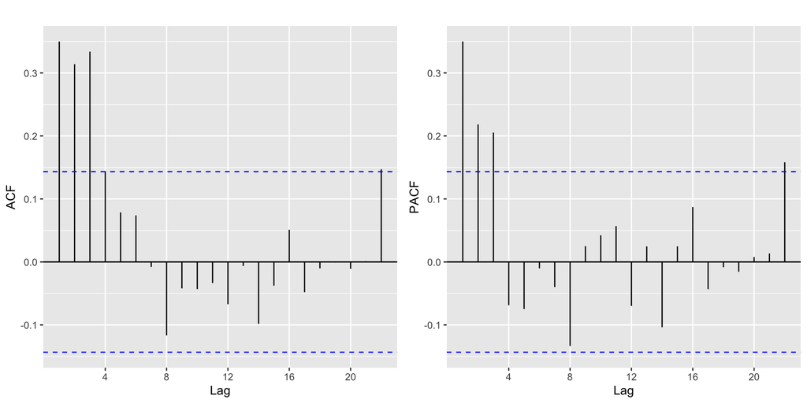

## ACF and PACF interpretation

**AR(1)**
$$rho_k =\phi_1^k \text{ for k=1,2,}\dots$$

$$\alpha_1= \phi_1 \alpha_k = 0\text{for k=2,3}\dots$$

So we have an AR(1) model when

- autocorrelations exponentially decay
- there is a single significant partial autocorrelation.

## ACF and PACF interpretation

- **AR(p)**
- ACF dies out in an exponential or damped sine-wave manner
- PACF has all zero spikes beyond the $p$th spike

So we have an AR(p)) model when

- the ACF is exponentially decaying or sinusoidal
- there is a significant spike at lag $p$ in PACF, but none beyond $p$

## **MA(1)** based on ACF and PACF

$$\begin{align*}
\rho_1 &= \theta_1 \qquad \rho_k = 0\qquad\text{for k=2,3,...};\\
\alpha_k &= -(-\theta_1)^k
\end{align*}$$

- So we have an MA(1) model when
- the PACF is exponentially decaying
- and there is a single significant spike in ACF

## More generally picking q for **MA(q)**

- PACF dies out in an exponential or damped sine-wave manner
- ACF has all zero spikes beyond the $q$th spike

So we have an MA(q) model when

- the PACF is exponentially decaying or sinusoidal
- there is a significant spike at lag $q$ in ACF, but none beyond $q$

## Information criteria for model selection

- In advanced financial modelling we use information theory to scientifically determine which of our model choices contains the most statistical information.

**Akaike’s Information Criterion (AIC):**

$\text{AIC} = -2 \log(L) + 2(p+q+k+1),$ where $L$ is the likelihood of the data, $k=1$ if $c\ne0$ and $k=0$ if $c=0$]

**Corrected AIC:**  
$\text{AICc} = \text{AIC} + \frac{2(p+q+k+1)(p+q+k+2)}{T-p-q-k-2}.$

## Information criteria for model selection

**Bayesian Information Criterion:**  
$\text{BIC} = \text{AIC} + [\log(T)-2](p+q+k-1).$  
Good models are obtained by minimizing either the AIC, AICc or BIC. My preference is to use the AICc.

## Powerful non-stationary model in finance

- In financial time series an important class on non-stationary times series model is the random walk model
- A random walk can be define as $y_t=y_{t-1}+ error_t$ or its drift variation $y_t= constant + y_{t-1}+ error_t$

## Simulation 1

```r
set.seed(1)
autoplot(10 + arima.sim(list(ar =0.99), n = 100))  + ylab("") +
  ggtitle("Is this a random walk with drift?")
```

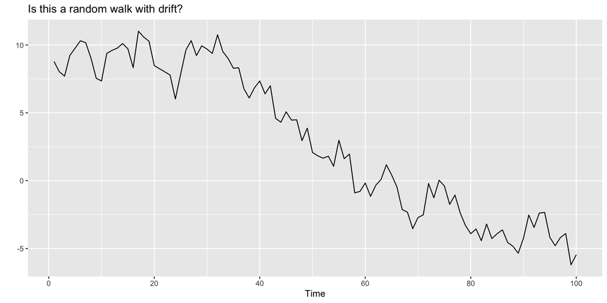

## Simulation 1

```r
set.seed(2)
S0=10
n=100
chgs=rnorm(n-1,1.001,0.01)
rw=ts(cumprod(c(S0,chgs)))
autoplot(rw)  + ylab("") +
  ggtitle("Is this a random walk with drift?")
```

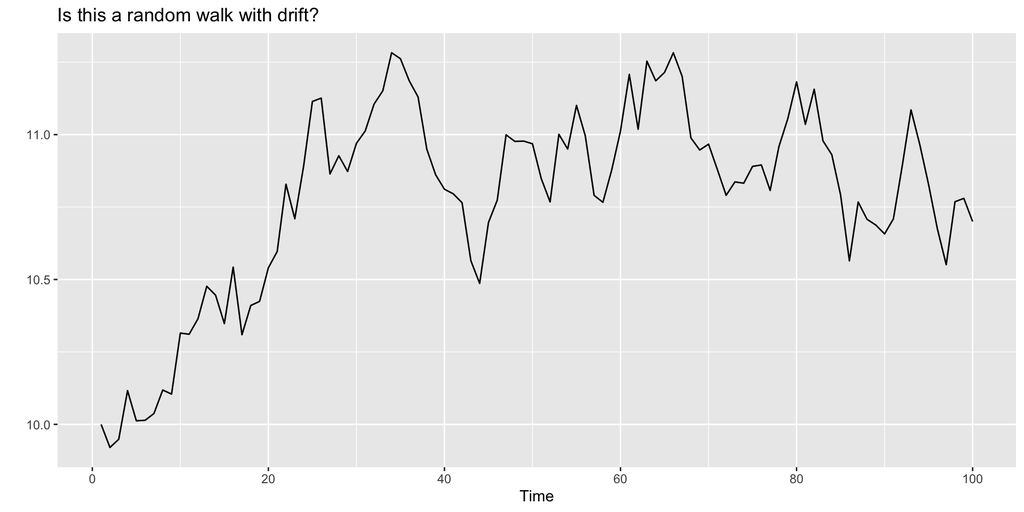

## AI automation for ARIMA models

- `auto.arima()`
- For a non-seasonal ARIMA process we first need to select appropriate orders: $p,q,d$
- We use the [Hyndman and Khandakar (JSS, 2008)](https://www.jstatsoft.org/article/view/v027i03) algorithm:
- Select no. differences $d$ and $D$ via KPSS test and seasonal strength measure.
- Select $p,q$ by minimising AICc.
- Use stepwise search to traverse model space.

## How does auto.arima() work?

$$\text{AICc} = -2 log(L) + 2(p+q+k+1)\left[1 +
\frac{(p+q+k+2)}{T-p-q-k-2}\right].$$

- where $L$ is the maximised likelihood fitted to the differenced data,
- $k=1$ if $c\neq 0$ and $k=0$ otherwise.

## Algorithmic rule 1:

- Select current model (with smallest AICc) from:
- ARIMA$(2,d,2)$
- ARIMA$(0,d,0)$
- ARIMA$(1,d,0)$
- ARIMA$(0,d,1)$

## Algorithmic rule 2:

- Consider variations of current model:
- vary one of $p,q,$ from current model by $\pm1$;
- $p,q$ both vary from current model by $\pm1$;
- Include/exclude $c$ from current model.
- Model with lowest AICc becomes current model.
- Repeat rule 2 until no lower AICc can be found

## Example: VIX index

## Get Data

```r
tidyquant::tq_get('^VIX') %>%
  select(adjusted) %>%
  ts() -> vix_ts
ggtsdisplay(log(vix_ts))
```

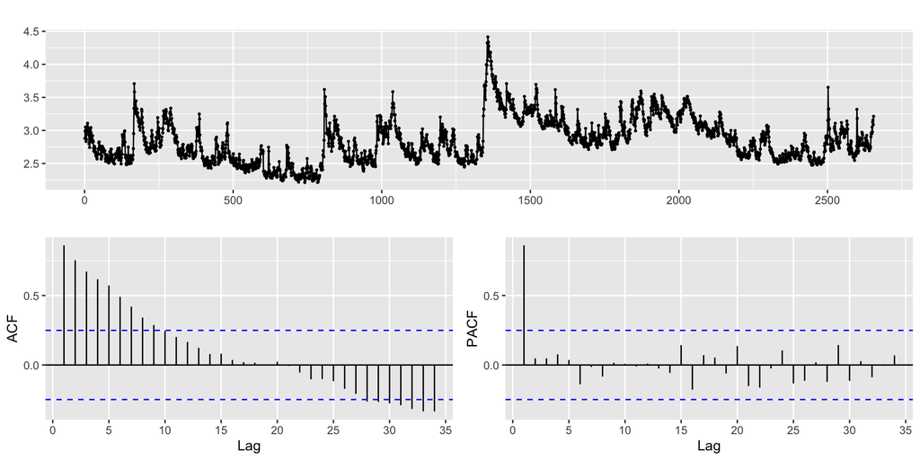

## Human choice

```r
ggtsdisplay(diff(log(vix_ts)))
```

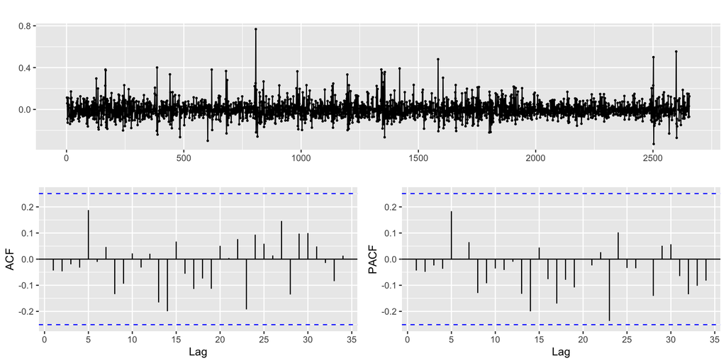

```r
ggtsdisplay(diff(log(vix_ts)))
```

## Human choice

```r
(fit <- Arima(log(vix_ts),order=c(7,1,0)))
```

```r
(fit <- Arima(log(vix_ts),order=c(7,1,0)))
```

```
Series: log(vix_ts)
ARIMA(7,1,0)

Coefficients:
          ar1      ar2      ar3      ar4      ar5      ar6      ar7
      -0.0658  -0.0632  -0.0282  -0.0561  -0.0201  -0.0543  -0.0250
s.e.   0.0198   0.0199   0.0199   0.0201   0.0202   0.0202   0.0204

sigma^2 = 0.006196:  log likelihood = 2845.73
AIC=-5675.47   AICc=-5675.41   BIC=-5628.39
```

## Algorithmic choice

```r
auto.arima(log(vix_ts))
```

```r
auto.arima(log(vix_ts))
```

```
Series: log(vix_ts)
ARIMA(0,1,1) with drift

Coefficients:
         ma1   drift
      -0.066  0.0001
s.e.   0.021  0.0014

sigma^2 = 0.006244:  log likelihood = 2833.58
AIC=-5661.16   AICc=-5661.16   BIC=-5643.51
```

## More careful algorthmic choice

```r
(fit.auto<-auto.arima(log(vix_ts),
                      stepwise=FALSE,
                      approximation=FALSE))
```

```r
(fit.auto<-auto.arima(log(vix_ts),
                      stepwise=FALSE,
                      approximation=FALSE))
```

```
Series: log(vix_ts)
ARIMA(2,1,3)

Coefficients:
         ar1     ar2      ma1      ma2     ma3
      0.1348  0.7615  -0.2086  -0.8175  0.0527
s.e.  0.1148  0.1053   0.1161   0.1059  0.0225

sigma^2 = 0.006141:  log likelihood = 2856.36
AIC=-5700.72   AICc=-5700.69   BIC=-5665.42
```

- Setting both `stepwise` and `approximation` arguments to `FALSE` will slow the automation down but provides a more exhaustive search for the appropriate model.
- The `auto.arima` function then searches over all possible models using MLE.
- See `help(auto.arima)` for more details.

## Human Vs Algo: Residual Diagnostics

### Human choice

```r
checkresiduals(fit, test=FALSE)
```

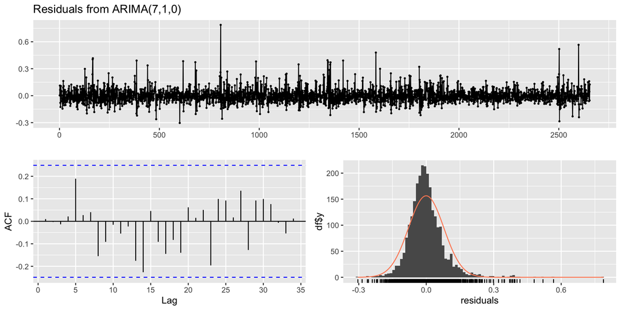

## Human forecasting

```r
fit %>% forecast(h=252) %>% autoplot
```

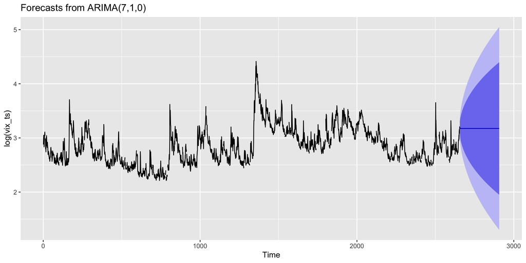

## Algorithm

```r
checkresiduals(fit.auto,test = FALSE)
```

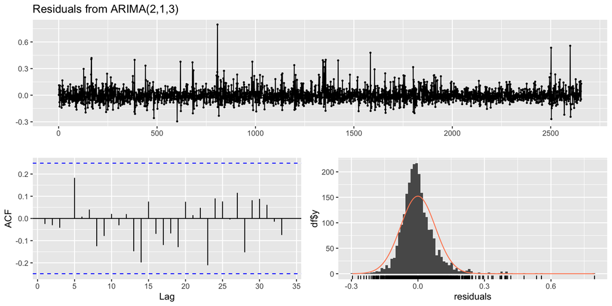

## Algo forecasting

```r
fit.auto %>% forecast(h=252) %>% autoplot()
```

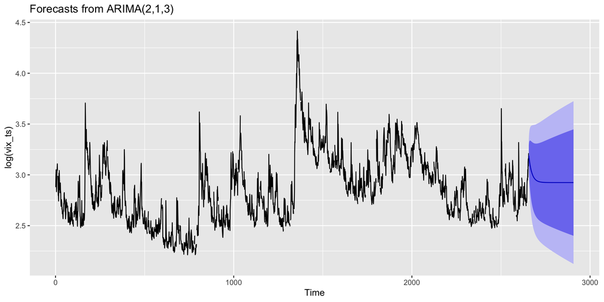

## Modelling procedure with `Arima`

### This is sometimes referred to as the Box-Jenkins approach

1. Plot the data. Identify any unusual observations.
2. If necessary, transform the data (using a Box-Cox transformation) to stabilize the variance.
3. If the data are non-stationary: take first differences of the data until the data are stationary.
4. Examine the ACF/PACF: Is an AR(p) or MA(q) model appropriate?
5. Try your chosen model(s), and use the AICc to search for a better model.
6. Check the residuals from your chosen model by plotting the ACF of the residuals, and doing a portmanteau test of the residuals. If they do not look like white noise, try a modified model.
7. Once the residuals look like white noise, calculate forecasts.

## Modelling procedure with `auto.arima`

1. Plot the data. Identify any unusual observations.
2. If necessary, transform the data (using logs) to stabilize the variance.
3. Use `auto.arima` to select a model.
4. Check the residuals from your chosen model by plotting the ACF of the residuals, and doing a portmanteau test of the residuals. If they do not look like white noise, try a modified model.
5. Once the residuals look like white noise, calculate forecasts.

## Project based example

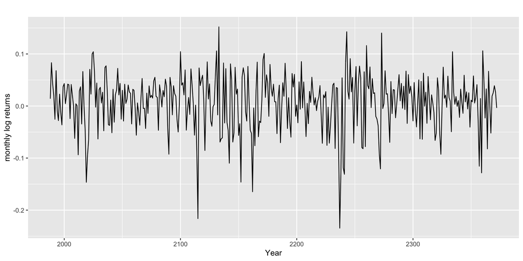

```r
tsfe::indices %>%
  select(date,`RUSSELL 2000 - PRICE INDEX`) %>%
  rename(r2000=`RUSSELL 2000 - PRICE INDEX`) %>%
  drop_na() %>%
  tq_transmute(select =r2000,mutate_fun = periodReturn,type='log') ->monthly_r2002r
  ts(monthly_r2002r$monthly.returns, start = c(1988,1))->r2000r_m_ts
autoplot(r2000r_m_ts) + xlab("Year") +
  ylab("monthly log returns")
```

1. Time plot shows sudden changes, particularly big movements in 2007/2008 due to financial crisis. Otherwise nothing unusual and no need for data adjustments.
2. Little evidence of changing variance, so no log transformation needed.
3. Data are clearly stationary, so no *differencing* required.

## Project based example

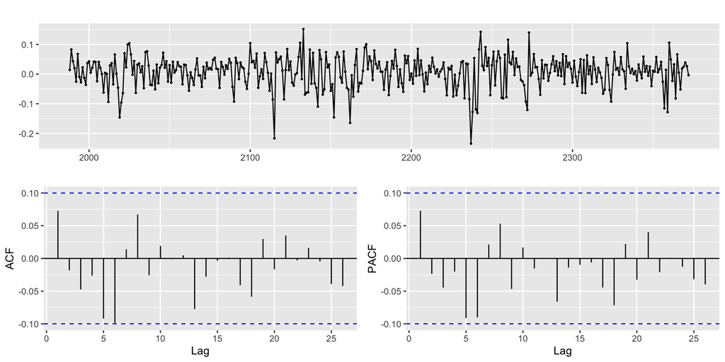

```r
ggtsdisplay(r2000r_m_ts)
```

4. PACF is suggestive of AR(5). So initial candidate model is ARIMA(5,0,0). No other obvious candidates.
5. Fit ARIMA(5,0,0) model along with variations: ARIMA(4,0,0), ARIMA(3,0,0), ARIMA(4,0,1), etc. ARIMA(3,0,1) has smallest *AICc* value.

## Project based example

### Manual fit

```r
(fit <- Arima(r2000r_m_ts, order=c(3,0,1)))
```

```r
(fit <- Arima(r2000r_m_ts, order=c(3,0,1)))
```

```
Series: r2000r_m_ts
ARIMA(3,0,1) with non-zero mean

Coefficients:
         ar1      ar2      ar3      ma1    mean
      1.0466  -0.0945  -0.0029  -1.0000  0.0062
s.e.  0.0509   0.0736   0.0511   0.0094  0.0004

sigma^2 = 0.002795:  log likelihood = 586.84
AIC=-1161.68   AICc=-1161.46   BIC=-1137.96
```

## Residual check

6. ACF plot of residuals from ARIMA(3,0,1) model look like white noise.

```r
checkresiduals(fit, plot=FALSE)
```

```
    Ljung-Box test

data:  Residuals from ARIMA(3,0,1) with non-zero mean
Q* = 7.5056, df = 6, p-value = 0.2766

Model df: 4.   Total lags used: 10
```

## Forecasting

```r
fit %>% forecast(h=24) %>% autoplot
```

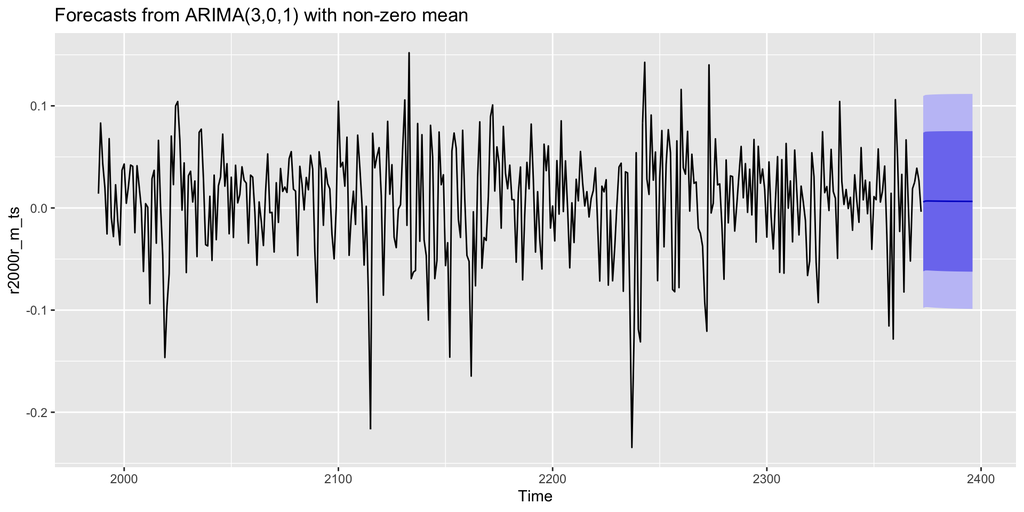

## Understanding the ARIMA output

```r
(fit <- Arima(r2000r_m_ts, order=c(3,0,1)))
```

```
Series: r2000r_m_ts
ARIMA(3,0,1) with non-zero mean

Coefficients:
         ar1      ar2      ar3      ma1    mean
      1.0466  -0.0945  -0.0029  -1.0000  0.0062
s.e.  0.0509   0.0736   0.0511   0.0094  0.0004

sigma^2 = 0.002795:  log likelihood = 586.84
AIC=-1161.68   AICc=-1161.46   BIC=-1137.96
```

## Understanding the ARIMA output

```r
a=unname(round(fit$coef["intercept"],3))
ar1=unname(round(fit$coef["ar1"],3))
ar2=unname(round(fit$coef["ar2"],3))
ar3=unname(round(fit$coef["ar3"],3))
ma1=unname(round(fit$coef["ma1"],3))
```

## Frequentist prediction intervals

$$\hat{y}_{T+h|T} \pm 1.96\sqrt{v_{T+h|T}}$$
where $v_{T+h|T}$ is estimated forecast variance.

- $v_{T+1|T}=\hat{\sigma}^2$ for all ARIMA models regardless of parameters and orders.
- Multi-step prediction intervals for ARIMA(0,0,$q$):

$$\displaystyle y_t = \varepsilon_t + \sum_{i=1}^q \theta_i \varepsilon_{t-i}$$

$$\displaystyle v_{T|T+h} = \hat{\sigma}^2 \left[ 1 + \sum_{i=1}^{h-1} \theta_i^2\right], \qquad\text{for~} h=2,3,\dots.$$

- AR(1): Rewrite as MA($\infty$) and use above result.
- Other models beyond scope of this subject.

## Prediction intervals

- Prediction intervals **increase in size with forecast horizon**.
- Prediction intervals can be difficult to calculate by hand
- Calculations assume residuals are **uncorrelated** and **normally distributed**.
- Prediction intervals tend to be too narrow.
  - the uncertainty in the parameter estimates has not been accounted for.
  - the ARIMA model assumes historical patterns will not change during the forecast period.
  - the ARIMA model assumes uncorrelated future $errors$

[figure not shown]

Advanced Financial Data Analytics